# Lab 09: Speeding things up

### Stat R 301

### June 4, 2013

### Eli Gurarie

For this lab, you'll need the following packages:

```r
require(Rcpp)
require(microbenchmark)
```

### Basics of R speed

Let's write three function that all get the difference in the mean of two groups:

```r
d.meanA <- function(Y, X) as.numeric(diff(tapply(Y, X, mean)))
d.meanB <- function(Y, X) mean(subset(Y, X == unique(X)[2])) - mean(subset(Y,
    X == unique(X)[1]))
d.meanC <- function(Y, X) sum(Y[X == unique(X)[2]])/sum(X == unique(X)[2]) -
    sum(Y[X == unique(X)[1]])/sum(X == unique(X)[1])

X <- factor(rep(c("A", "B"), each = 10000))
Y <- runif(length(X))

d.meanA(Y, X)
```

```
## [1] 0.001715
```

```r
d.meanB(Y, X)
```

```
## [1] 0.001715
```

```r
d.meanC(Y, X)
```

```
## [1] 0.001715
```

Recall the helpful `system.time` function:

```r
system.time(d.meanA(Y, X))
```

```
##    user  system elapsed
##    0.03    0.00    0.03
```

```r
system.time(d.meanB(Y, X))
```

```
##    user  system elapsed
##    0.02    0.00    0.01
```

```r
system.time(d.meanC(Y, X))
```

```
##    user  system elapsed
##    0.04    0.00    0.03
```

The functions are too fast! We can add some repetitions, but that takes time, and is tedious to type out:

```r
system.time(for (i in 1:100) d.meanA(Y, X))
```

```
##    user  system elapsed
##    2.34    0.00    2.45
```

```r
system.time(for (i in 1:100) d.meanB(Y, X))
```

```
##    user  system elapsed
##    1.81    0.00    1.86
```

```r
system.time(for (i in 1:100) d.meanC(Y, X))
```

```
##    user  system elapsed
##    2.67    0.00    2.92
```

There is a convenient little package called `microbenchmark` that allows you to compare very fast (sub-millisecond) operations:

```r
microbenchmark(d.meanA(Y, X), d.meanB(Y, X), d.meanC(Y, X), times = 10)
```

```
## Unit: milliseconds
##           expr   min    lq median    uq   max neval
##  d.meanA(Y, X) 19.74 21.35  22.46 23.91 30.78    10
##  d.meanB(Y, X) 15.40 16.19  17.02 17.49 23.36    10
##  d.meanC(Y, X) 23.30 26.02  26.78 27.10 92.74    10
```

There is not such a great difference, though the last one is definitely slowest. To really pry into why, you need to profile the code:

```r
Rprof("rprof.out")
for (i in 1:100) d.meanC(Y, X)
Rprof(NULL)
summaryRprof("rprof.out")
```

```
$by.self
                 self.time self.pct total.time total.pct
"Ops.factor"          1.44    51.43       2.14     76.43
"NextMethod"          0.64    22.86       0.64     22.86
"d.meanC"             0.26     9.29       2.80    100.00
"unique.default"      0.20     7.14       0.36     12.86
"levels"              0.06     2.14       0.06      2.14
"factor"              0.04     1.43       0.10      3.57
"nlevels"             0.04     1.43       0.10      3.57
"sort.int"            0.04     1.43       0.04      1.43
"unique"              0.02     0.71       0.38     13.57
"["                   0.02     0.71       0.02      0.71
"length"              0.02     0.71       0.02      0.71
"noNA.levels"         0.02     0.71       0.02      0.71

$by.total
                 total.time total.pct self.time self.pct
"d.meanC"              2.80    100.00      0.26     9.29
"Ops.factor"           2.14     76.43      1.44    51.43
"=="                   2.14     76.43      0.00     0.00
"NextMethod"           0.64     22.86      0.64    22.86
"unique"               0.38     13.57      0.02     0.71
"unique.default"       0.36     12.86      0.20     7.14
"factor"               0.10      3.57      0.04     1.43
"nlevels"              0.10      3.57      0.04     1.43
"levels"               0.06      2.14      0.06     2.14
"sort.int"             0.04      1.43      0.04     1.43
"["                    0.02      0.71      0.02     0.71
"length"               0.02      0.71      0.02     0.71
"noNA.levels"          0.02      0.71      0.02     0.71

$sample.interval
[1] 0.02

$sampling.time
[1] 2.8
```

You can see from this output that there is an `Ops.factor` function that is taking a large amount of time

```r
microbenchmark(d.meanC(Y, X), d.meanC(Y, as.numeric(X)), times = 10)
```

```
## Unit: milliseconds
##                       expr    min     lq median    uq   max neval
##              d.meanC(Y, X) 21.997 23.876  24.26 24.99 26.66    10
##  d.meanC(Y, as.numeric(X))  9.735  9.912  11.63 12.03 12.52    10
```

You see (through this example) that we learned an important principle - that the very existence of a factor class slows things down. R profiling is useful for discovering all sorts of these little things.

### General tips on speeding up R

First - ask yourself if its worth it!:

1. If you're spending more time trying to optimize than you gain my optimizing, you're no longer optimizing!
2. Remember, there are often trade-offs between readability and speed. You will see this principle
3. Really spending time optimizing is only worth it if you are passing a function you wrote yourself many many times, in a non-vectorizable way … OR if you are performing operations on some very large objects.

Ok, some nitty gritty grits:

- *integers* are faster than *factors* (see above, but #2!)
- *matrices* are faster to work with than *data.frames* (but #2!)

```r
microbenchmark(tapply(data.frame(X, Y)$Y, X, mean), tapply(cbind(X, Y)[, 2],
    X, mean), times = 1)
```

```
## Unit: milliseconds
##                                 expr   min    lq median    uq   max neval
##  tapply(data.frame(X, Y)$Y, X, mean) 27.03 27.03  27.03 27.03 27.03     1
##    tapply(cbind(X, Y)[, 2], X, mean) 23.41 23.41  23.41 23.41 23.41     1
```

- base functions are faster than higher-level functions (with more controls):

```r
microbenchmark(mean(Y), sum(Y)/length(Y))
```

```
## Unit: microseconds
##              expr    min     lq median     uq   max neval
##           mean(Y) 125.50 128.57 168.22 196.52 217.5   100
##  sum(Y)/length(Y)  54.66  60.05  83.15  96.62 194.4   100
```

Why is `mean` slower? Because of all the controls.

```r
mean
```

```
## function (x, ...)
## UseMethod("mean")
## <bytecode: 0x0000000006601f30>
## <environment: namespace:base>
```

```r
methods(mean)
```

```
## [1] mean.Date     mean.default  mean.difftime mean.POSIXct  mean.POSIXlt
```

```r
mean.default
```

```
## function (x, trim = 0, na.rm = FALSE, ...)
## {
##     if (!is.numeric(x) && !is.complex(x) && !is.logical(x)) {
##         warning("argument is not numeric or logical: returning NA")
##         return(NA_real_)
##     }
##     if (na.rm)
##         x <- x[!is.na(x)]
##     if (!is.numeric(trim) || length(trim) != 1L)
##         stop("'trim' must be numeric of length one")
##     n <- length(x)
##     if (trim > 0 && n) {
##         if (is.complex(x))
##             stop("trimmed means are not defined for complex data")
##         if (any(is.na(x)))
##             return(NA_real_)
##         if (trim >= 0.5)
##             return(stats::median(x, na.rm = FALSE))
##         lo <- floor(n * trim) + 1
##         hi <- n + 1 - lo
##         x <- sort.int(x, partial = unique(c(lo, hi)))[lo:hi]
##     }
##     .Internal(mean(x))
## }
## <bytecode: 0x00000000066cab20>
## <environment: namespace:base>
```

- Pre-assign vectors and fill them in, rather than creating them on the fly. For example, here is a discrete model of population growth:

$$x_{t+1} = x_t \exp{r(1-x_t)}$$

This model has some unexpected dynamics (off-topic here, but see, for example: http://www.r-bloggers.com/dynamical-systems-mapping-chaos-with-r/):

```r
chaos1 <- function(r,x0,n) {
  x <- x0
  for(i in 2:n)
    x[i] <- x[i-1]*exp(r*(1-x[i-1]))
  return(x)
}
```

At growth rates of $r>2$ there are multiple stable states, and at even higher growth rates the system becomes chaotic. Anyways, make a small change:

```r
chaos2 <- function(r,x0,n) {
  x <- c(x0, rep(0,n-1))
  for(i in 2:n)
  x[i] <- x[i-1]*exp(r*(1-x[i-1]))
  return(x)
}
```

and benchmark:

```r
microbenchmark(chaos1(4, 0.5, 10000), chaos2(4, 0.5, 10000), times = 1)
```

```
## Unit: milliseconds
##                   expr   min    lq median    uq   max neval
##  chaos1(4, 0.5, 10000) 406.5 406.5  406.5 406.5 406.5     1
##  chaos2(4, 0.5, 10000) 120.8 120.8  120.8 120.8 120.8     1
```

A significant improvement (that scales with the length of the vector)!

Less nitty - but also good suggestions:

- Use a high powered package (e.g. `data.table` or something called `xts` or `Matrix` for matrix computations).
- Get a bigger computer.
- Use parallel processing (e.g. `snow`).
- Finally, when all else fails … use a compiled language!

## Incorporating C++ with Rcpp

*Disclosure: this portion of the lab is heavily plagiarized from Hadley Wickham's guide: https://github.com/hadley/devtools/wiki/Rcpp*

Here's what Hadley Wickham says:

> When should you use C++ (or another compiled language)?
> - **Iterative Loops**, i.e. loops that can't be vectorised they depends on the previous result. Unlike R (which constatly writes, erases, rewrites in memoty) C++ modifies objects in place, so there is little overhead when modifying a data structure many times.
> - **Recursive functions**, i.e. problems which involve calling functions millions of times. The overhead of calling a function in C++ is much lower than the overhead of calling a function in R.
> - **Advanced data structures** Problems that require advanced data structures and algorithms that R doesn't provide. Through the standard template library (STL), C++ has efficient implementations of many important data structures, from ordered maps to double ended queues.

In the past, you would have to separately write and compile C code, and call it from R using the `.C` function (give `?.C` a quick look to see what that entails).

In these, enlightened times, there is a package called `Rcpp`, by Dirk Eddelbuettel and Romain Francois, which allows “seamless” integration of C++ and R.

See (and revisit frequently) `vignette("Rcpp-introduction")` and `vignette("Rcpp-package")` for good reference material, and http://dirk.eddelbuettel.com/code/rcpp/html/index.html for complete documentation of Rcpp.

### Creating a simple C function in R …

is easy:

```r
cppFunction('
  int add(int x, int y, int z) {
    int sum = x + y + z;
    return sum;
  }'
)
```

We've just added a function called `add` to our environment:

```r
add
```

```
## function (x, y, z)
## .Primitive(".Call")(<pointer: 0x00000000677414e0>, x, y, z)
```

Test it:

```r
add(1, 2, 3)
```

```
## [1] 6
```

Note that this function will ONLY work on integers, and therefore does things that you might not expect:

```r
add(1.1, 2.2, 3.9)
```

```
## [1] 6
```

This is (once again) a place where what a *programmer* things is great (i.e. strict definition of variable types), a *user / normal person* thinks is very strange. But it gives you a good idea of the trade-off between rigor and speed.

### A super brief intro to C++ (from someone that DOES NOT really know it!)

Let's start with a very simple function. It has no arguments and always returns the the integer 1:

```r
one <- function() 1L
```

Note that the `L` in R coerces an integer type:

```r
is.integer(1)
```

```
## [1] FALSE
```

```r
is.integer(1L)
```

```
## [1] TRUE
```

The equivalent C++ function is:

```r
int one() {
  return 1;
}
```

which we can compile and use this from R with cppFunction

```r
cppFunction('
  int one() {
    return 1;
  }
')
```

This small function illustrates a number of important differences (and similarities) between R and C++:

- The syntax to create a function looks like the syntax to call a function; you don't use assignment to create functions like in R.
- You must declare the type of output the function returns. This function returns an int (a scalar integer). The classes for the most common types of R vectors are: `NumericVector`, `IntegerVector`, `CharacterVector` and `LogicalVector`.
- Scalars and vectors are different. The scalar equivalents of *numeric*, *integer*, *character* and *logical* vectors are: `double`, `int`, `String` and `bool`.
- You must use an explicit return statement to return a value from the function.
- Every statement is terminated by a ;. Vector input, scalar output

One big difference between R and C++ is that the cost of loops is much lower. For example, we could implement the sum function in R using a loop. If you've been programming in R a while, you'll probably have a visceral reaction to this function!

```r
sumR <- function(x) {
    total <- 0
    for (i in 1:length(x)) {
        total <- total + x[i]
    }
    total
}
```

In C++, loops have very little overhead, so it's fine to use them!

```r
cppFunction('
  double sumC(NumericVector x) {
    int n = x.size();
    double total = 0;
    for(int i = 0; i < n; ++i) {
      total += x[i];
    }
    return total;
  }
')
```

The C++ version is similar, but:

- To find the length of the vector, we use the size() method, which returns an integer. Again, whenever we create a new variable we have to tell C++ what type of object it will hold. An `int` is a scalar integer, but we could have used `double` for a scalar numeric, `bool` for a scalar logical, or a `String` for a scalar string.
- The `for` statement has a different syntax: `for(intialisation; condition; increase)`. The `initialise` component creates a new variable called `i` and sets it equal to 0. The condition is checked in each iteration of the loop: the loop continues while it's true. The `increase` statement is run after each loop iteration, but before the condition is checked. Here we use the special prefix operator `++` which increases the value of `i` by 1.
- Vectors in C++ start at 0. I'll say this again because it's so important: VECTORS IN C++ START AT 0! This is a very common source of bugs when converting R functions to C++.
- We can't use <- (or ->) for assignment, but instead use =.
- We can take advantage of the in-place modification operators: `total += x[i]` is equivalent to `total = total + x[i]`. Similar in-place operators are `-=`, `*=` and `/=`. This is known as a side-effect, where the function `++` or `+=` modifies its argument `i` or `x` without us asking. Functions in R rarely have side-effects, and we need to be careful that our Rcpp functions don't modify their inputs. More on that later.

This is a good example of where C++ is much more efficient than the R equivalent. As shown by the following microbenchmark, our sumC function is competitive with the built-in (and highly optimised) sum function, while sumR is several orders of magnitude slower.

```r
x <- runif(1000)
microbenchmark(sum(x), sumR(x), sumC(x))
```

```
## Unit: microseconds
##     expr      min       lq  median       uq     max neval
##   sum(x)    3.465    3.851    5.39    6.931  222.50   100
##  sumR(x) 2035.629 2102.996 2198.27 2820.162 4589.79   100
##  sumC(x)    6.160    7.315   11.74   19.248   96.62   100
```

### Practice!

Write a straightforward function that obtains the n'th Fibonacci sum in R:

```r
FibSumR <- function(n) {
    F1 <- 0
    F2 <- 1
    F <- F2
    for (i in 1:(n - 1)) {
        F <- F1 + F2
        F1 <- F2
        F2 <- F
    }
    F
}
```

Write a nice primitive loop in C++.

```r
cppFunction('
  int FibSumC(int n) {
    int F1 = 0;
    int F2 = 1;
    int F = 1;
    for(int i = 0; i < n-1; ++i)
    {
      F = F1+F2;
      F1 = F2;
      F2 = F;
    }
    return F;
  }')
```

Perform the `microbenchmark` on these:

```r
microbenchmark(FibSumR(35), FibSumC(35), times = 100)
```

```
## Unit: microseconds
##         expr   min     lq median      uq    max neval
##  FibSumR(35) 87.77 88.925 92.775 128.960 253.69   100
##  FibSumC(35)  3.08  4.235  5.583   7.893  79.69   100
```

Note that the difference in median speeds is almost 20-fold. All the ANGST associated with writing loops in R can be set aside! *Note, there are without doubt better ways to code this, both in R and in C++ - but these seem good enough.*

### Separate source code compilation

Of course, as a programmer, you might prefer to separately write nice compilable C++ code (e.g. in a good code editor - though if you install Rcpp, you will get a C++ code editor in RStudio) and just use it from inside R.

Then using `sourceCpp("path/to/file.cpp")` will compile the C++ code, create the matching R functions and add them to your current session.

A few rules about your source file: it should have extension .cpp, and needs to start with:

```r
#include <Rcpp.h>
using namespace Rcpp;
```

Also, to appear in your workspace, it must somewhat strangely lead off with the following apparent comment command:

```r
// [[Rcpp::export]]
```

For a (simple) example, here is a mean function:

```r
#include <Rcpp.h>
using namespace Rcpp;

// [[Rcpp::export]]
double meanC(NumericVector x) {
  int n = x.size();
  double total = 0;

  for(int i = 0; i < n; ++i) {
    total += x[i] / n;
  }
  return total;
}
```

Now we can source and benchmark this function:

```r
sourceCpp("meanC.cpp")
x <- runif(1e+05)
microbenchmark(mean(x), meanC(x))
```

```
## Unit: microseconds
##      expr    min     lq median     uq    max neval
##   mean(x)  533.2  541.2  555.1  608.2  867.7   100
##  meanC(x) 1845.5 1863.7 1876.3 1928.4 5181.5   100
```

*Not too impressive! Probably way to improve it (using higher level functions in C++) but I don't know how!*

### Continuous time-series likelihood

Let's walk through an example of using C++ code for an application that was relevant to my own research (see - if you're really bored: http://www.ncbi.nlm.nih.gov/pubmed/19379134).

Within the context of a larger estimation, I was interested in estimating a correlation coefficient $\phi$ from an AR(1) time-series $X_i$ observed at irregular times $T_i$. As an example a “true” AR(1) process whith $\phi=0.9$ and 1000 datapoints, of which we only observe 100 pts:

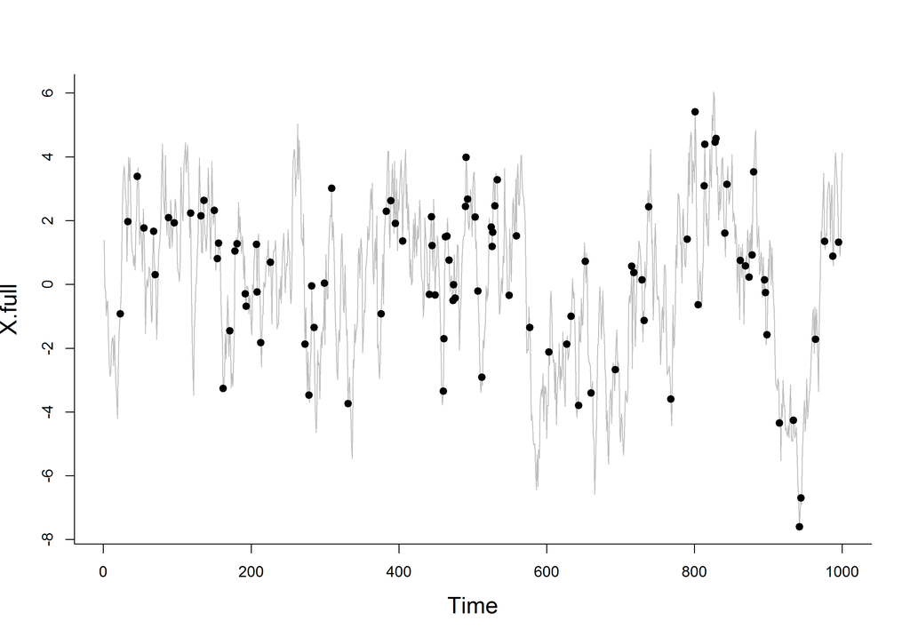

```r
X.full <- arima.sim(list(ar = 0.9), 1000)
T <- sort(sample(1:length(X.full), 100))
X <- X.full[T]
plot(X.full, col = "grey")
points(T, X, pch = 19)
```

So $X_i$ is a series of observations made at times $T_i$. Good estimates for the mean and variance are $\widehat{\mu} = \overline{X}$, and for $\widehat{\sigma^2} = s_x^2$. Because of what we know about AR(1) time-series, I also know that:

$$\text{Cor}(X(t), X(t-\tau)) = \rho^\tau$$
With some - basically - algebra, we get a conditional distributoin function for $X_i|X_{i-1}$ as:
$$f(X_i|X_{i-1}) = {1\over \widehat\sigma\sqrt{2 \pi (1-\rho^{2\tau_i})}} \exp {\left(\left(X_i - \rho^{\tau_i} (X_{i-1}-\widehat\mu)\right)^2 \over 2\widehat\sigma^2 (1 - \rho^{2\tau_i})\right)}.$$

Which means I can find an estimate for $\rho$ by maximizing this likelihood:

$$L(\rho|X,T,\widehat{\mu}, \widehat{\sigma}) = \prod_{i=1}^n f(X_i|X_{i-1},\tau_i,\rho, \widehat{\mu}, \widehat{\sigma})$$

where $X}$ and $T$ represent the vector of observations and times of observation and the distribution function $f$ is thedensity function of the conditional distribution $X_i|X_{i-1}$ above.

To do this in R, I need a function for the likelihood:

```r
GetLL <- function(x, t, rho) {
    mu <- mean(x)
    s <- sd(x)
    dt <- diff(t)
    n <- length(x)
    x.plus <- x[-1]
    x.minus <- x[-length(x)]
    Likelihood <- dnorm(x.plus, mean = mu + (rho^dt) * (x.minus - mu), sd = s *
        sqrt(1 - rho^(2 * dt)))
    LL <- sum(log(Likelihood))
    return(LL)
}
```

So we can plot the likelihood for different values of $\rho$

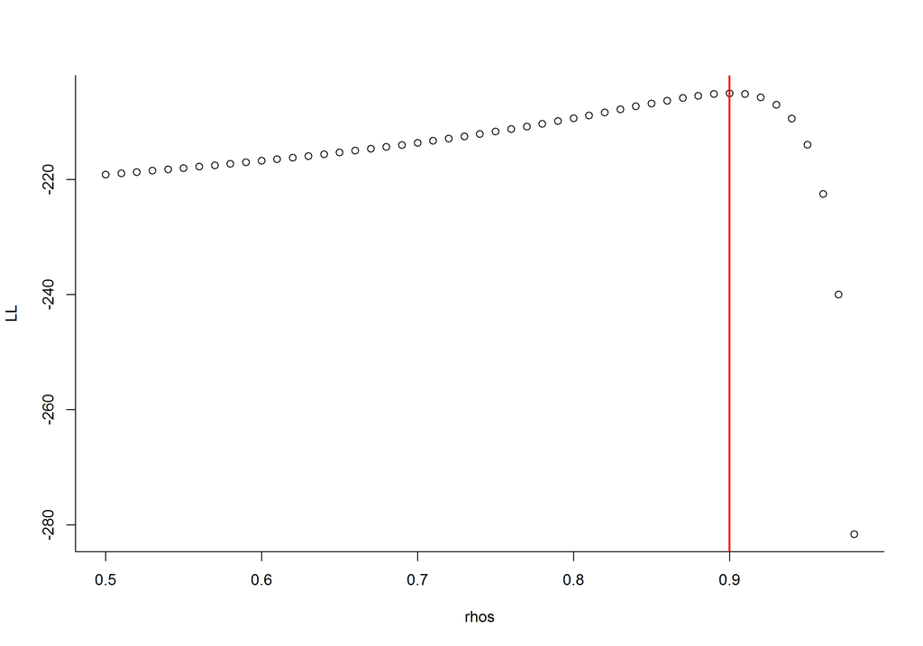

```r
rhos <- seq(0.5, 0.98, 0.01)
LL <- c()
for (i in 1:length(rhos)) LL[i] <- GetLL(X, T, rhos[i])
plot(rhos, LL)
abline(v = rhos[which.max(LL)], col = 2, lwd = 2)
```

The likelihood is maximized near the true value (0.9), so it looks like a pretty good guess.

To automatically find this likelihood, we need to run `optimize` on this

```r
GetRho <- function(x, t) {
    getL <- function(rho) {
        logL <- GetLL(x, t, rho)
        return(-logL)
    }

    o <- optimize(getL, lower = 0, upper = 1, tol = 1e-04)
    return(c(o$minimum, o$objective))
}
GetRho(X, T)
```

```
## [1]   0.9004 205.0472
```

This is a more precise estimate.

Now, this is all well and good, but in my anlysis I need to estimate $\rho$ up to tens of thousands of times, and things became if not prohibitively, then definitely molassessy slow. So, eventually I wrote a C++ function just for the log likelihood. It took me way too long to do, and compared to the, essentially, 2-liner in R is ridiculously long and ugly:

```r
#include <Rcpp.h>
#include <math.h>

using namespace Rcpp;
RNGScope scope;

NumericVector SubSet(NumericVector A, int start, int end)
{
  NumericVector B(A.begin() + start, A.begin() + end);
    return B;
}

double DNorm(double x, double mu, double sigma)
{
    double pdf = 1.0 / ( sigma * sqrt(2.0 * M_pi) ) * exp( -0.5 * pow( (x-mu)/sigma, 2.0 ) );
    return pdf;
}

// [[Rcpp::export]]
double GetLcpp(NumericVector x, NumericVector t, double rho)
{
    NumericVector Time(t);
    NumericVector X(x);
    double Rho = rho;

    int N = Time.size()-1;

    double mux = mean(X);
    double sigmax = sd(X);

    NumericVector dT(N);
    NumericVector RhoToTheDt(N);

    NumericVector Xstart = SubSet(X, 0, N);
    NumericVector Xend = SubSet(X, 1, N+1);
    dT = diff(Time);

    for(int i = 0; i < N; i++)
    RhoToTheDt[i] = pow(Rho, dT[i]);

    NumericVector Mu = RhoToTheDt*(Xstart-mux) + mux;
    NumericVector Sigma = sigmax*sqrt(1-RhoToTheDt*RhoToTheDt);

    double LL = 0;

    for(int i = 0; i < N; i++)
   LL = LL + log(DNorm(Xend[i], Mu[i], Sigma[i]));

    return LL;
}
```

There's a lot of hyper-explicit coding here. For example, I had to create my own `DNorm` function. I had to change the length of vectors (with `SubSet`), and on and on. Probably someone in this class can help improve this code!

Anyways, here's the implementation:

```r
sourceCpp("GetLc.cpp")
GetRho2 <- function(x, t) {
    getLc <- function(rho) {
        logL <- GetLc(x, t, rho)
        return(-logL)
    }

    o <- optimize(getLc, lower = 0, upper = 1, tol = 1e-04)
    return(c(o$minimum, o$objective))
}
GetRho2(X, T)
```

```
## [1]   0.9004 205.0472
```

So it gives the same result (which is good).

```r
microbenchmark(GetRho(X, T), GetRho2(X, T))
```

```
## Unit: milliseconds
##           expr   min    lq median    uq   max neval
##   GetRho(X, T) 4.380 4.619  5.142 6.636 10.94   100
##  GetRho2(X, T) 1.036 1.070  1.116 1.353 17.23   100
```

And it does it almost 5 times faster. This was a big time saving for me, because this little estimation would be repeated so much that an analysis would took 10 minutes, now (after this and other tightening tweaks), takes 1 minute.

So a lot of pain, but definitely worth it!